[figure not shown]

# Severe Heat Days using the Universal Thermal Comfort Index

**Author:** Marcial Yangali (marcialy@colmex.mx)

**Reviewers:** Landy Sánchez and Emerson Baptista

## Overview

This Code & Data is part of the [CACHE](https://agingclimatehealth.org/) research initiative on Aging, Climate, and Health, specifically the demonstration project on [Heat, Disability in Older Adults, and Care](https://agingclimatehealth.org/heat-disability-in-older-adults-and-care/). This entry shows how to construct heat measures using the Universal Thermal Comfort Index (UTCI). We detail the data **wrangling, analysis, and visualization process in R** used to construct the variable *days of severe heat* define as any day reaching 32° C of UTCI or above (strong, very strong, or extreme heat stress). We demonstrate this process with data from Mexico, but, of course, the procedure can be replicated for any other part of the world.

## Required R Packages 🛠️

We begin by loading the necessary R packages. These support data manipulation (mainly [`dplyr`](https://dplyr.tidyverse.org/) but also [`janitor`](https://cran.r-project.org/web/packages/janitor/index.html), [`stringr`](https://stringr.tidyverse.org) , [`tidyr`](https://tidyr.tidyverse.org), [`lubridate`](https://lubridate.tidyverse.org/) and [`forcats`](https://forcats.tidyverse.org)), visualization ([`ggplot2`](https://ggplot2.tidyverse.org/), [`patchwork`](https://cran.r-project.org/web/packages/patchwork/index.html)), and geospatial operations ([`sf`](https://cran.r-project.org/web/packages/sf/index.html), [`units`](https://cran.r-project.org/web/packages/units/index.html), [`terra`](https://cran.r-project.org/web/packages/terra/index.html)).

```r
if (!require("pacman")) install.packages("pacman")
pacman::p_load(
  # Data handling
  dplyr, janitor, stringr, tidyr, forcats, lubridate, purrr,
  # Visualization
  ggplot2, patchwork,
  # Spatial data
  sf,
  units,
  terra)
```

## Heat Data

### 1. Universal Thermal Climate Index (UTCI)

The [Universal Thermal Climate Index (UTCI)](https://climate-adapt.eea.europa.eu/es/metadata/indicators/thermal-comfort-indices-universal-thermal-climate-index-1979-2019) is a bioclimatic index that evaluates the physiological comfort of the human body under certain meteorological conditions [(Brödel et al. 2012)](https://link.springer.com/article/10.1007/s00484-011-0454-1). The UTCI is derived from the UTCI-Fiala model [(Fiala et al., 2012)](https://link.springer.com/article/10.1007/s00484-011-0424-7), which integrates a dynamic thermoregulation framework of the human body along with a clothing insulation model that varies with temperature. Overall, UTCI offers an assessment of the “apparent” temperature that our body would perceive in specific environmental conditions, specifically, air temperature, wind, humidity, and radiation.

As the UTCI incorporates more variables affecting thermal comfort, it seeks to provide a more realistic picture of the thermal stress perceived by the humans and their behavioral responses, particularly in outdoor conditions. Compared to other heat indices, UTCI is more robust and flexible in capturing thermal stress across a wide range of climates and extreme weather conditions. Due to its adaptability and comprehensive design, UTCI was selected as the primary measure to evaluate heat stress in our study across Mexican municipalities.

```r
# We save the names of the raster images in a list
files <- list.files("in/UTCI", pattern = "\\.nc$", full.names = TRUE)
```

### 2. Geographic Data – Mexican Municipalities and States

In order to spatially visualize the distribution of heat exposure, we use official geographic boundaries at the municipal and state levels from the [2020 Census](https://www.inegi.org.mx/app/biblioteca/ficha.html?upc=889463807469). We are using the shapefiles `00mun` and `00ent` from the downloaded folder: `mg_2020_integrado/conjunto_de_datos`.

```r
# Municipal geometries
mapa <- read_sf("in/GEO/00mun.shp") |>
  st_transform(st_crs(4326)) |>
  clean_names()
# State level geometries
mapa2 <- read_sf("in/GEO/00ent.shp") |>
  st_transform(st_crs(4326))
```

## From Raster to Vector Data

We begin by exploring one of the raster images we have downloaded:

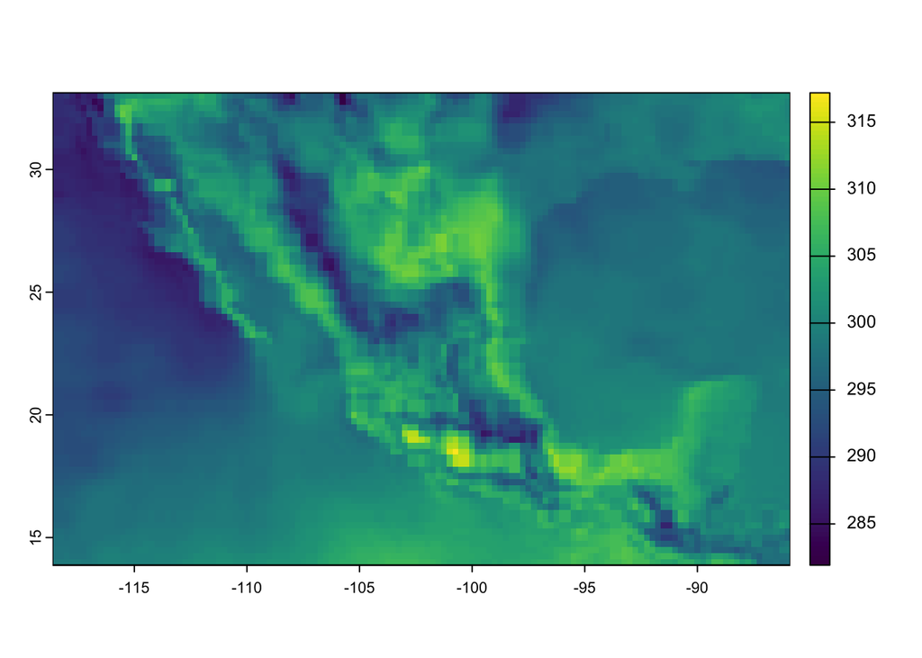

```r
# 1. Open a NetCDF file and store it as object 'r'
r <- rast(files[1]) # SpatRaster object

# 1.1. Visualize the raster layer
plot(r[[1]])
```

The image reveals the pixel size (0.25 x 0.25 degrees). We will use these dimensions to create a regular grid of square polygons and examine how they intersect with the geometries of Mexico.

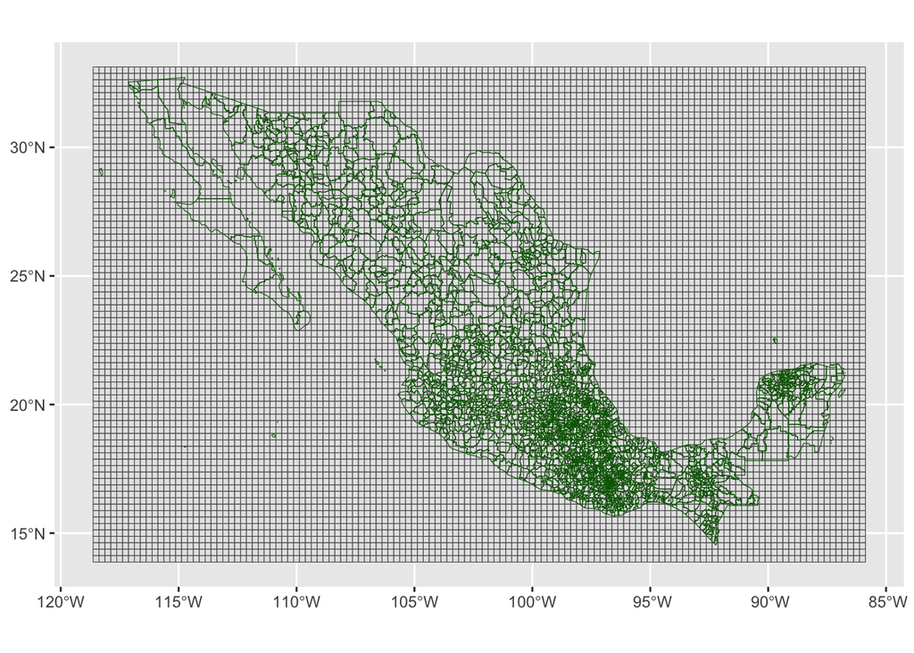

```r
# 2. Get the center coordinates of each cell
coords <- as.data.frame(r, xy = TRUE, cells = TRUE)[, c("x", "y", "cell")]

# 3. Create polygons (0.25° x 0.25° squares) centered on each point
res <- 0.25  # resolution in degrees

# Use purrr::pmap to build each polygon
polys <- coords |>
  mutate(
    geometry = purrr::pmap(list(x, y), function(x, y) {
      st_polygon(list(matrix(c(
        x - res/2, y - res/2,
        x + res/2, y - res/2,
        x + res/2, y + res/2,
        x - res/2, y + res/2,
        x - res/2, y - res/2
      ), ncol = 2, byrow = TRUE)))
    })
  )

# 4. Convert to an sf object
grid <- st_sf(ID = polys$cell, geometry = st_sfc(polys$geometry, crs = 4326))

grid |>
  ggplot() +
  geom_sf() +
  geom_sf(data = mapa, fill = NA, color = "darkgreen")
```

### Weighted Values

To obtain a summary value per municipality (e.g., daily mean or maximum UTCI), we must account for all pixels within each municipal boundary. However, values must be adjusted according to the proportion of each pixel that lies within a given municipality — the *weight*. These weights are calculated using `st_intersection()`. Due to the complexity of municipal polygons, this operation may take considerable time. It is highly recommended to perform it once and save the result:

**⚠️ This is the time-consuming step:**

```r
wgrid <- st_intersection(
     grid |> select(ID),
     mapa |> select(CVEGEO))

st_write(wgrid, "in/wgrid.shp")
```

Once the intersection is completed, we calculate the proportion of each polygon’s area used as weight:

```r
wgrid <- st_read("in/wgrid.shp")

weights_df <- wgrid |>
    mutate(
      area = st_area(geometry),
      weight = as.numeric(area) / as.numeric(st_area(wgrid[match(ID, wgrid$ID), ]))
    ) |>
    st_drop_geometry() |>
    select(ID, CVEGEO, weight)
```

#### Creating a Function to Process UTCI Files

Now we define a function to process a NetCDF file and compute weighted UTCI values for each municipality:

```r
process_utci_with_intersection <- function(path_nc, weights_df) {
  r <- terra::rast(path_nc)
  utci_day <- max(r) - 273.15  # Convert from Kelvin to Celsius

  # Extract values
  df_utci <- as.data.frame(utci_day, xy = TRUE, cells = TRUE)

  df_utci <- df_utci |>
    rename(ID = cell, MAX = 4)  # The fourth column contains the value

  # Convert to sf
  utci_sf <- st_as_sf(df_utci, coords = c("x", "y"), crs = crs(r)) |>
    st_transform(4326)

  # Join with weights
  df_merge <- inner_join(utci_sf, weights_df,
                         by = "ID")

  # Aggregate by municipality
  df_mun <- df_merge |>
    group_by(CVEGEO) |>
    summarise(
      MAX = sum(MAX * weight, na.rm = TRUE) / sum(weight[!is.na(MAX)]),
      .groups = "drop"
    )

  # Extract and add date
  fecha <- stringr::str_extract(basename(path_nc), "\\d{8}")
  df_mun$DATE <- as.Date(fecha, format = "%Y%m%d")

  return(df_mun)
}
```

### Applying the Function to 31 Days of Data

We apply the function to the 31 UTCI raster files downloaded for May 2019:

```r
# Apply function
UTCI_mun <- purrr::map_dfr(
    files,
    ~process_utci_with_intersection(.x, weights_df))
```

Finally, we extract the day, month, and year from the DATE variable. This step will be especially useful as we incorporate additional months and years into the analysis, allowing for easier temporal aggregation, filtering, and visualization across multiple time scales.

```r
UTCI_mun <- UTCI_mun |>
  mutate(DATE = as.Date(DATE)) |>
  mutate(
    YEAR = year(DATE),
    MONTH = month(DATE),
    DAY = day(DATE)
  ) |>
  st_drop_geometry()
```

#### 📈 Plot 1: UTCI Distribution – Average, Percentiles and Heat Threshold

We plot:

- Mean daily maximun UTCI
- 25th and 75th percentiles (in light gray)
- A fixed 32°C threshold (horizontal red line)

[figure not shown]

```r
# Percentile bands and thresholds
UTCI_mun |>
  group_by(YEAR, MONTH, DAY) |>
  summarise(
    MeanMAX = mean(MAX),
    MAX25 = quantile(MAX, .25, na.rm = TRUE),
    MAX75 = quantile(MAX, .75, na.rm = TRUE)
  ) |>
  ungroup() |>
  ggplot() +
  geom_line(aes(x = DAY, y = MeanMAX), linewidth = 0.85) +
  geom_line(aes(x = DAY, y = MAX25), color = "gray") +
  geom_line(aes(x = DAY, y = MAX75), color = "gray") +
  geom_hline(yintercept = 32, color = "red", linewidth = 0.85, alpha = 0.9) +
  scale_y_continuous(limits = c(17, 40),
                     breaks = seq(10,40,1)) +
  scale_x_continuous(breaks = seq(1, 31, by = 1)) +
  theme_bw() +
  labs(
    x = "Day of the Month",
    y = "UTCI (Daily Maximum)",
    title = "Average UTCI in Mexico by Day of May (2019)",
    subtitle = "Red: Absolute threshold (32°C)",
    caption = "Source: UTCI based on ERA5 reanalysis data. Own elaboration."
  ) +
  theme(strip.background = element_rect(fill = "white"),
        strip.text = element_text(face = "bold", size = 11))
```

📌 *During May, the absolute threshold (32°C) is exceeded by all the daily averages.*

#### 🗺️ Map 1: Average UTCI by Municipality

As a first spatial exploration, we plot the average daily maximum UTCI for each municipality. This provides a baseline spatial understanding of where thermal comfort conditions tend to be most extreme.

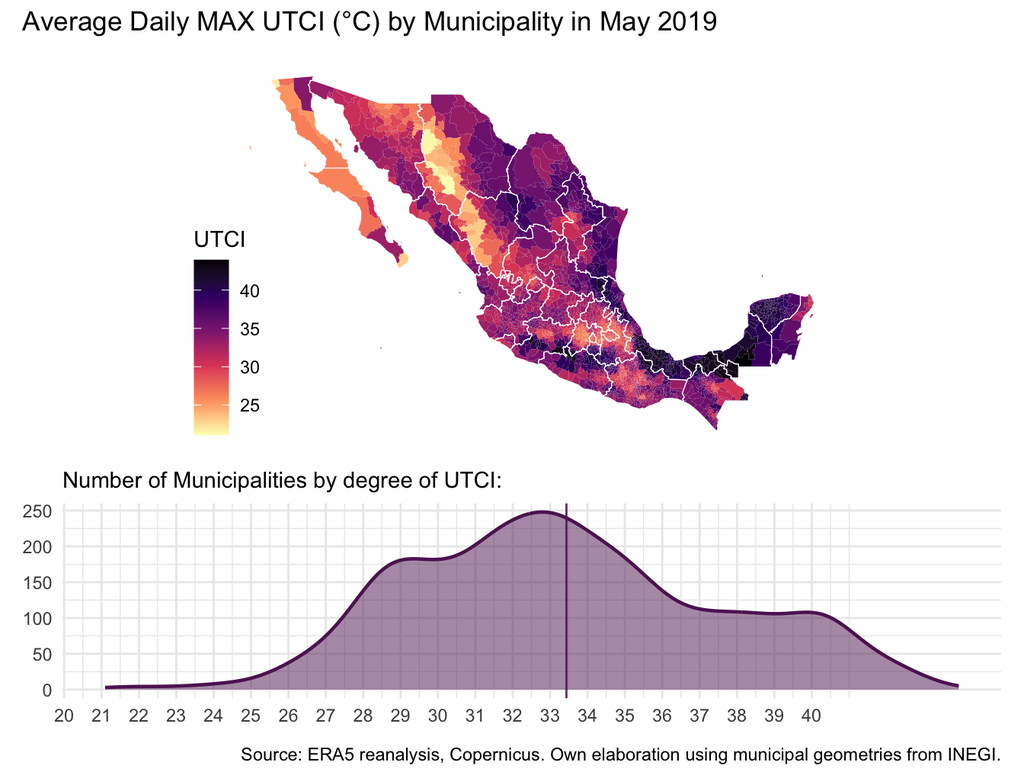

```r
# Average MAX UTCI
summary <- UTCI_mun |>
  group_by(YEAR) |>
  summarise(Mean = mean(MAX, na.rm = TRUE)) |>
  ungroup() |>
    st_drop_geometry()

# Map
map <- mapa |>
    rename(CVEGEO = cvegeo) |>
    # Fast merge
  left_join(UTCI_mun |>
  group_by(CVEGEO, YEAR) |>
  summarise(Mean = mean(MAX, na.rm = TRUE)) |>
  ungroup() |>
      mutate(CVEGEO = str_pad(CVEGEO, width = 5,
                            side = "left", pad = "0")),
  by = c("CVEGEO")) |>
    # Plot:
    ggplot() +
  geom_sf(aes(fill = Mean), color = NA) +
  geom_sf(data = mapa2, fill = NA, color = "white", linewidth = 0.2) +
  scale_fill_viridis_c(option = "magma",
                       direction = -1,
                       name = "UTCI") +
    theme_void() +
    theme(legend.position = c(.01,.3),
          plot.background = element_rect(fill = "white",
                                         color = "white"),
          plot.margin = unit(c(.2, .2, .2, .2),
                             "cm"))

# Distribution
dist <- UTCI_mun |>
  group_by(CVEGEO, YEAR) |>
  summarise(Mean = mean(MAX, na.rm = TRUE)) |>
  ungroup() |>
      mutate(CVEGEO = str_pad(CVEGEO, width = 5,
                            side = "left", pad = "0")) |>
    # Plot:
    ggplot() +
    geom_density(aes(x = Mean, y = ..count..),
                 fill = "#5d1f61",
                 color = "#5d1f61",
                 linewidth = .8,
                 alpha = .5) +
    geom_vline(xintercept = summary$Mean[1],
               color = "#5d1f61", alpha = .85)+
    scale_x_continuous(breaks = seq(20,40,1))+
  labs(subtitle = "Number of Municipalities by degree of UTCI:",
      color = NULL,
      fill = NULL,
       y = NULL,
       x = NULL)+
    theme_minimal() +
    theme(legend.position = c(.9,.7))
# Paste Maps and Distribution using patchwork library:
map/dist+plot_layout(heights = c(2.4,1.2))+
    plot_annotation(title = "Average Daily MAX UTCI (°C) by Municipality in May 2019",
       caption = "Source: ERA5 reanalysis, Copernicus. Own elaboration using municipal geometries from INEGI.")
```

📌 *This map reveals consistent regional patterns, with higher levels of heat stress in coastal and southeastern areas of Mexico.*